# BANK FRAUD DATA PROCESSING STATS PROJECT

Jairo Onate

2024-09-18

#### Group 1 members: Jairo Onate, John Pole Madhu, Ajay Katta

## 1. Obtaining Data

The dataset used for this analysis was sourced from **Kaggle** through the following link: [**Bank Account Fraud Dataset**](https://www.kaggle.com/datasets/sgpjesus/bank-account-fraud-dataset-neurips-2022). Kaggle is a well-known platform that provides a wide range of datasets for data analysis, machine learning, and research.

The dataset, titled *Bank Account Fraud Dataset (NeurIPS 2022)*, is part of the **NeurIPS 2022 competition** and is focused on the detection of fraudulent activities associated with bank accounts.

**Data Collection Process** **Source:** The data was downloaded directly from the Kaggle website. The dataset is publicly available, meaning anyone can access it. **Collection Method:** The dataset was manually downloaded in CSV format after accessing the public page on Kaggle. **Tools Used:** The data was downloaded manually using a web browser and imported into the analysis environment ( R Lab ) for further exploration and analysis.

**Summary of Data Source and Collection** **Source:** Kaggle, Bank Account Fraud Dataset (NeurIPS 2022). **Type of Data:** Pre-processed CSV files that are ready for analysis. **Collection Process:** Manual download from Kaggle. **Purpose:** The dataset is structured to help detect fraudulent activities in bank accounts, making it a suitable candidate for machine learning models focused on fraud detection.

A more detailed explanation of the data collection process, including the file structure and preliminary data exploration, can be found in the sections below.

## 2. Cleaning and Preprocessing:

```r
library(purrr)
library(readr)

# bankfraud_compiled <- dir(path = "/Users/jairoonatebarrios/Documents/BDA 610 ADVANCED BUSINESS STATISTICS/PROJECT DATA/BANK FRAUD CSV", full.names = TRUE) %>% map_df(read_csv)

bankfraud_base <- read_csv(file = '/Users/jairoonatebarrios/Documents/BDA 610 ADVANCED BUSINESS STATISTICS/PROJECT DATA/BANK FRAUD CSV/Base.csv', col_names = TRUE)
```

```r
library(dplyr)

str(bankfraud_base)
```

```
## spc_tbl_ [1,000,000 × 32] (S3: spec_tbl_df/tbl_df/tbl/data.frame)
##  $ fraud_bool                      : num [1:1000000] 0 0 0 0 0 0 0 0 0 0 ...
##  $ income                          : num [1:1000000] 0.3 0.8 0.8 0.6 0.9 0.6 0.2 0.8 0.3 0.8 ...
##  $ name_email_similarity           : num [1:1000000] 0.987 0.617 0.997 0.475 0.842 ...
##  $ prev_address_months_count       : num [1:1000000] -1 -1 9 11 -1 -1 22 -1 21 -1 ...
##  $ current_address_months_count    : num [1:1000000] 25 89 14 14 29 369 4 103 2 134 ...
##  $ customer_age                    : num [1:1000000] 40 20 40 30 40 30 40 40 30 20 ...
##  $ days_since_request              : num [1:1000000] 0.00674 0.0101 0.01232 0.00699 5.74263 ...
##  $ intended_balcon_amount          : num [1:1000000] 102.45 -0.85 -1.49 -1.86 47.15 ...
##  $ payment_type                    : chr [1:1000000] "AA" "AD" "AB" "AB" ...
##  $ zip_count_4w                    : num [1:1000000] 1059 1658 1095 3483 2339 ...
##  $ velocity_6h                     : num [1:1000000] 13096 9223 4471 14432 7602 ...
##  $ velocity_24h                    : num [1:1000000] 7851 5745 5472 6755 5124 ...
##  $ velocity_4w                     : num [1:1000000] 6742 5942 5993 5970 5941 ...
##  $ bank_branch_count_8w            : num [1:1000000] 5 3 15 11 1 705 28 6 2 14 ...
##  $ date_of_birth_distinct_emails_4w: num [1:1000000] 5 18 11 13 6 5 8 7 10 20 ...
##  $ employment_status               : chr [1:1000000] "CB" "CA" "CA" "CA" ...
##  $ credit_risk_score               : num [1:1000000] 163 154 89 90 91 134 72 163 35 201 ...
##  $ email_is_free                   : num [1:1000000] 1 1 1 1 0 1 1 0 0 1 ...
##  $ housing_status                  : chr [1:1000000] "BC" "BC" "BC" "BC" ...
##  $ phone_home_valid                : num [1:1000000] 0 1 0 0 1 1 1 1 1 1 ...
##  $ phone_mobile_valid              : num [1:1000000] 1 1 1 1 1 1 1 1 0 1 ...
##  $ bank_months_count               : num [1:1000000] 9 2 30 1 26 30 1 25 2 15 ...
##  $ has_other_cards                 : num [1:1000000] 0 0 0 0 0 0 0 1 0 0 ...
##  $ proposed_credit_limit           : num [1:1000000] 1500 1500 200 200 200 200 200 200 200 1500 ...
##  $ foreign_request                 : num [1:1000000] 0 0 0 0 0 0 0 0 0 0 ...
##  $ source                          : chr [1:1000000] "INTERNET" "INTERNET" "INTERNET" "INTERNET" ...
##  $ session_length_in_minutes       : num [1:1000000] 16.22 3.36 22.73 15.22 3.74 ...
##  $ device_os                       : chr [1:1000000] "linux" "other" "windows" "linux" ...
##  $ keep_alive_session              : num [1:1000000] 1 1 0 1 0 1 1 1 1 1 ...
##  $ device_distinct_emails_8w       : num [1:1000000] 1 1 1 1 1 1 1 1 1 1 ...
##  $ device_fraud_count              : num [1:1000000] 0 0 0 0 0 0 0 0 0 0 ...
##  $ month                           : num [1:1000000] 0 0 0 0 0 0 0 0 0 0 ...
##  - attr(*, "spec")=
##   .. cols(
##   ..   fraud_bool = col_double(),
##   ..   income = col_double(),
##   ..   name_email_similarity = col_double(),
##   ..   prev_address_months_count = col_double(),
##   ..   current_address_months_count = col_double(),
```

[output cut: 14 more lines]

```
##   ..   phone_home_valid = col_double(),
##   ..   phone_mobile_valid = col_double(),
##   ..   bank_months_count = col_double(),
##   ..   has_other_cards = col_double(),
##   ..   proposed_credit_limit = col_double(),
##   ..   foreign_request = col_double(),
##   ..   source = col_character(),
##   ..   session_length_in_minutes = col_double(),
##   ..   device_os = col_character(),
##   ..   keep_alive_session = col_double(),
##   ..   device_distinct_emails_8w = col_double(),
##   ..   device_fraud_count = col_double(),
##   ..   month = col_double()
##   .. )
##  - attr(*, "problems")=<externalptr>
```

```r
which(is.na(bankfraud_base))
```

```
## integer(0)
```

```r
sum(is.na(bankfraud_base))
```

```
## [1] 0
```

```r
bankfraud_base_nomissing <- bankfraud_base %>%filter(
       prev_address_months_count > -1 ,
       current_address_months_count > -1,
       intended_balcon_amount > -1,
       velocity_6h > -1,
       bank_months_count > -1,
       session_length_in_minutes > -1,
       device_distinct_emails_8w > -1)
str(bankfraud_base_nomissing)
```

```
## spc_tbl_ [124,260 × 32] (S3: spec_tbl_df/tbl_df/tbl/data.frame)
##  $ fraud_bool                      : num [1:124260] 0 0 0 0 0 0 0 0 0 0 ...
##  $ income                          : num [1:124260] 0.2 0.3 0.2 0.6 0.6 0.9 0.7 0.7 0.8 0.6 ...
##  $ name_email_similarity           : num [1:124260] 0.7731 0.5237 0.5278 0.7729 0.0307 ...
##  $ prev_address_months_count       : num [1:124260] 22 21 13 96 48 49 26 235 287 90 ...
##  $ current_address_months_count    : num [1:124260] 4 2 114 124 5 8 14 29 13 35 ...
##  $ customer_age                    : num [1:124260] 40 30 20 40 20 20 20 30 30 20 ...
##  $ days_since_request              : num [1:124260] 0.00692 0.03521 0.00317 0.01549 0.00831 ...
##  $ intended_balcon_amount          : num [1:124260] -0.545 -0.956 -0.848 -0.96 -0.793 ...
##  $ payment_type                    : chr [1:124260] "AB" "AB" "AB" "AB" ...
##  $ zip_count_4w                    : num [1:124260] 1998 1781 4389 4033 3601 ...
##  $ velocity_6h                     : num [1:124260] 11724 6980 12256 7412 9483 ...
##  $ velocity_24h                    : num [1:124260] 7864 4336 5391 5991 5370 ...
##  $ velocity_4w                     : num [1:124260] 6339 6625 6331 6373 6373 ...
##  $ bank_branch_count_8w            : num [1:124260] 28 2 1839 0 5 ...
##  $ date_of_birth_distinct_emails_4w: num [1:124260] 8 10 18 3 16 11 13 23 15 14 ...
##  $ employment_status               : chr [1:124260] "CA" "CA" "CA" "CB" ...
##  $ credit_risk_score               : num [1:124260] 72 35 49 245 142 114 162 18 200 173 ...
##  $ email_is_free                   : num [1:124260] 1 0 0 0 1 1 0 1 1 1 ...
##  $ housing_status                  : chr [1:124260] "BC" "BC" "BB" "BA" ...
##  $ phone_home_valid                : num [1:124260] 1 1 1 0 1 0 0 0 0 1 ...
##  $ phone_mobile_valid              : num [1:124260] 1 0 1 1 1 1 1 1 1 1 ...
##  $ bank_months_count               : num [1:124260] 1 2 15 28 20 1 20 11 1 3 ...
##  $ has_other_cards                 : num [1:124260] 0 0 0 0 0 0 0 0 0 0 ...
##  $ proposed_credit_limit           : num [1:124260] 200 200 200 1500 500 500 500 1000 1500 200 ...
##  $ foreign_request                 : num [1:124260] 0 0 0 0 0 0 0 0 0 0 ...
##  $ source                          : chr [1:124260] "INTERNET" "INTERNET" "INTERNET" "INTERNET" ...
##  $ session_length_in_minutes       : num [1:124260] 28.2 5.33 2.84 4.61 3.1 ...
##  $ device_os                       : chr [1:124260] "x11" "other" "windows" "other" ...
##  $ keep_alive_session              : num [1:124260] 1 1 1 1 1 1 1 1 1 1 ...
##  $ device_distinct_emails_8w       : num [1:124260] 1 1 2 1 1 1 1 1 1 1 ...
##  $ device_fraud_count              : num [1:124260] 0 0 0 0 0 0 0 0 0 0 ...
##  $ month                           : num [1:124260] 0 0 0 0 0 0 0 0 0 0 ...
##  - attr(*, "spec")=
##   .. cols(
##   ..   fraud_bool = col_double(),
##   ..   income = col_double(),
##   ..   name_email_similarity = col_double(),
##   ..   prev_address_months_count = col_double(),
##   ..   current_address_months_count = col_double(),
```

[output cut: 14 more lines]

```
##   ..   phone_home_valid = col_double(),
##   ..   phone_mobile_valid = col_double(),
##   ..   bank_months_count = col_double(),
##   ..   has_other_cards = col_double(),
##   ..   proposed_credit_limit = col_double(),
##   ..   foreign_request = col_double(),
##   ..   source = col_character(),
##   ..   session_length_in_minutes = col_double(),
##   ..   device_os = col_character(),
##   ..   keep_alive_session = col_double(),
##   ..   device_distinct_emails_8w = col_double(),
##   ..   device_fraud_count = col_double(),
##   ..   month = col_double()
##   .. )
##  - attr(*, "problems")=<externalptr>
```

#### Dictionary

- **income (numeric):** Annual income of the applicant (in decile form). Ranges between [0.1, 0.9].
- **name_email_similarity (numeric):** Metric of similarity between email and applicant’s name. Higher values represent higher similarity. Ranges between [0, 1].
- **prev_address_months_count (numeric):** Number of months in previous registered address of the applicant, i.e. the applicant’s previous residence, if applicable. Ranges between [−1, 380] months (-1 is a missing value).
- **current_address_months_count (numeric):** Months in currently registered address of the applicant. Ranges between [−1, 429] months (-1 is a missing value).
- **customer_age (numeric):** Applicant’s age in years, rounded to the decade. Ranges between [10, 90] years.
- **days_since_request (numeric):** Number of days passed since application was done. Ranges between [0, 79] days.
- **intended_balcon_amount (numeric):** Initial transferred amount for application. Ranges between [−16, 114] (negatives are missing values).
- **payment_type (categorical):** Credit payment plan type. 5 possible (annonymized) values.
- **zip_count_4w (numeric):** Number of applications within same zip code in last 4 weeks. Ranges between [1, 6830].
- **velocity_6h (numeric):** Velocity of total applications made in last 6 hours i.e., average number of applications per hour in the last 6 hours. Ranges between [−175, 16818].
- **velocity_24h(numeric):** Velocityoftotalapplicationsmadeinlast24hoursi.e.,average number of applications per hour in the last 24 hours. Ranges between [1297, 9586]
- **velocity_4w (numeric):** Velocity of total applications made in last 4 weeks, i.e., average number of applications per hour in the last 4 weeks. Ranges between [2825, 7020].
- **bank_branch_count_8w (numeric):** Number of total applications in the selected bank branch in last 8 weeks. Ranges between [0, 2404].
- **date_of_birth_distinct_emails_4w (numeric):** Number of emails for applicants with same date of birth in last 4 weeks. Ranges between [0, 39].
- **employment_status (categorical):** Employment status of the applicant. 7 possible (annonymized) values.
- **credit_risk_score (numeric):** Internal score of application risk. Ranges between [−191, 389].
- **email_is_free (binary):** Domain of application email (either free or paid).
- **housing_status (categorical):** Current residential status for applicant. 7 possible (annonymized) values.
- **phone_home_valid (binary):** Validity of provided home phone.
- **phone_mobile_valid (binary):** Validity of provided mobile phone.
- **bank_months_count (numeric):** How old is previous account (if held) in months. Ranges between [−1, 32] months (-1 is a missing value).
- **has_other_cards (binary):** If applicant has other cards from the same banking com- pany.
- **proposed_credit_limit (numeric):** Applicant’s proposed credit limit. Ranges between [200, 2000].
- **foreign_request (binary):** If origin country of request is different from bank’s country. - source (categorical): Online source of application. Either browser (INTERNET) or app (TELEAPP).
- **session_length_in_minutes (numeric):** Length of user session in banking website in minutes. Ranges between [−1, 107] minutes (-1 is a missing value).
- **device_os (categorical):** Operative system of device that made request. Possible values are: Windows, macOS, Linux, X11, or other.
- **keep_alive_session (binary):** User option on session logout.
- **device_distinct_emails (numeric):** Number of distinct emails in banking website from the used device in last 8 weeks. Ranges between [−1, 2] emails (-1 is a missing value). - device_fraud_count (numeric): Number of fraudulent applications with used device. Ranges between [0, 1].
- **month (numeric):** Month where the application was made. Ranges between [0, 7]. - fraud_bool (binary): If the application is fraudulent or not.

## 3. Summary Statistics:

```r
summary(bankfraud_base_nomissing)
```

```
##    fraud_bool           income       name_email_similarity
##  Min.   :0.000000   Min.   :0.1000   Min.   :0.0000014
##  1st Qu.:0.000000   1st Qu.:0.4000   1st Qu.:0.2199508
##  Median :0.000000   Median :0.7000   Median :0.4733199
##  Mean   :0.002318   Mean   :0.5979   Mean   :0.4872083
##  3rd Qu.:0.000000   3rd Qu.:0.8000   3rd Qu.:0.7464696
##  Max.   :1.000000   Max.   :0.9000   Max.   :0.9999986
##  prev_address_months_count current_address_months_count  customer_age
##  Min.   :  6.00            Min.   :  0.00               Min.   :10.00
##  1st Qu.: 26.00            1st Qu.:  6.00               1st Qu.:20.00
##  Median : 33.00            Median : 11.00               Median :30.00
##  Mean   : 60.64            Mean   : 24.87               Mean   :30.74
##  3rd Qu.: 66.00            3rd Qu.: 19.00               3rd Qu.:40.00
##  Max.   :377.00            Max.   :416.00               Max.   :90.00
##  days_since_request intended_balcon_amount payment_type        zip_count_4w
##  Min.   : 0.00000   Min.   : -1.0000       Length:124260      Min.   :   2
##  1st Qu.: 0.00685   1st Qu.: -0.7357       Class :character   1st Qu.: 805
##  Median : 0.01467   Median :  6.3341       Mode  :character   Median :1244
##  Mean   : 1.71439   Mean   : 18.8311                          Mean   :1480
##  3rd Qu.: 0.02691   3rd Qu.: 33.7956                          3rd Qu.:1832
##  Max.   :76.29663   Max.   :112.2531                          Max.   :6563
##   velocity_6h        velocity_24h   velocity_4w   bank_branch_count_8w
##  Min.   :   10.89   Min.   :1431   Min.   :2969   Min.   :   0.0
##  1st Qu.: 3266.46   1st Qu.:3701   1st Qu.:4313   1st Qu.:   6.0
##  Median : 5422.67   Median :4887   Median :4988   Median :  13.0
##  Mean   : 5711.54   Mean   :4883   Mean   :4912   Mean   : 202.2
##  3rd Qu.: 7975.98   3rd Qu.:5950   3rd Qu.:5489   3rd Qu.:  38.0
##  Max.   :16416.96   Max.   :9374   Max.   :6995   Max.   :2351.0
##  date_of_birth_distinct_emails_4w employment_status  credit_risk_score
##  Min.   : 0.00                    Length:124260      Min.   :-147.0
##  1st Qu.: 7.00                    Class :character   1st Qu.:  81.0
##  Median :10.00                    Mode  :character   Median : 122.0
##  Mean   :10.52                                       Mean   : 127.5
##  3rd Qu.:14.00                                       3rd Qu.: 169.0
##  Max.   :39.00                                       Max.   : 366.0
##  email_is_free  housing_status     phone_home_valid phone_mobile_valid
##  Min.   :0.00   Length:124260      Min.   :0.0000   Min.   :0.000
##  1st Qu.:0.00   Class :character   1st Qu.:0.0000   1st Qu.:1.000
##  Median :1.00   Mode  :character   Median :0.0000   Median :1.000
##  Mean   :0.53                      Mean   :0.3416   Mean   :0.914
```

[output cut: 15 more lines]

```
##                     Max.   :82.47862
##  keep_alive_session device_distinct_emails_8w device_fraud_count
##  Min.   :0.0000     Min.   :0.00              Min.   :0
##  1st Qu.:0.0000     1st Qu.:1.00              1st Qu.:0
##  Median :1.0000     Median :1.00              Median :0
##  Mean   :0.5954     Mean   :1.02              Mean   :0
##  3rd Qu.:1.0000     3rd Qu.:1.00              3rd Qu.:0
##  Max.   :1.0000     Max.   :2.00              Max.   :0
##      month
##  Min.   :0.000
##  1st Qu.:2.000
##  Median :3.000
##  Mean   :3.195
##  3rd Qu.:5.000
##  Max.   :7.000
```

## 4. Data Visualization:

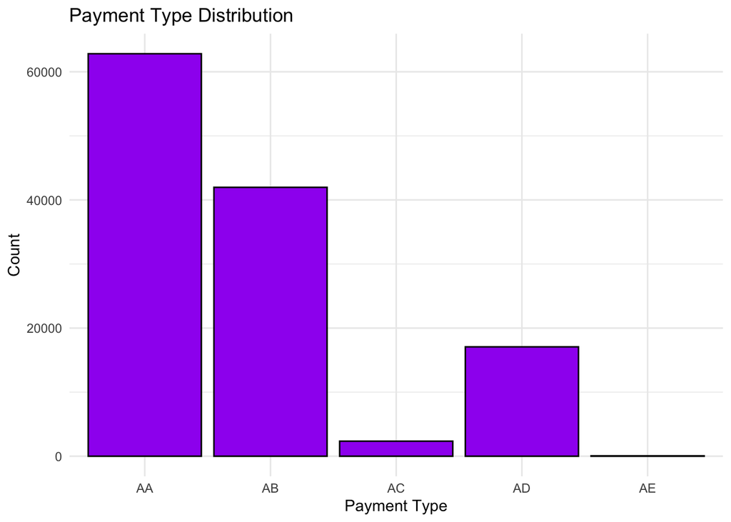

```r
library(ggplot2)

# Bar plot for payment_type

ggplot(bankfraud_base_nomissing, aes(x = payment_type)) +
  geom_bar(fill = "purple", color = "black") +
  theme_minimal() +
  labs(title = "Payment Type Distribution", x = "Payment Type", y = "Count")
```

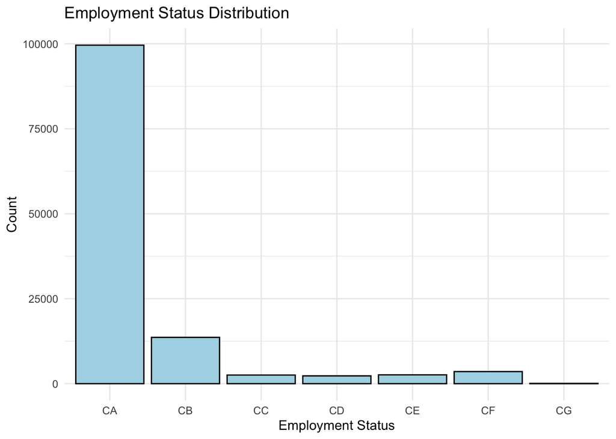

```r
# Bar plot for employment_status
ggplot(bankfraud_base_nomissing, aes(x = employment_status)) +
  geom_bar(fill = "lightblue", color = "black") +
  theme_minimal() +
  labs(title = "Employment Status Distribution", x = "Employment Status", y = "Count")
```

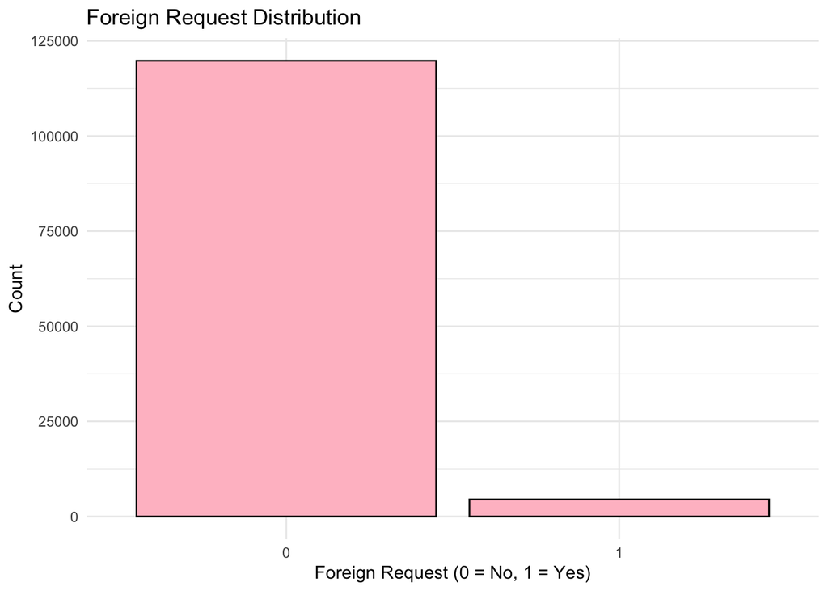

```r
# Bar plot for foreign_request (assuming it's binary, e.g., 0 = No, 1 = Yes)
ggplot(bankfraud_base_nomissing, aes(x = factor(foreign_request))) +
  geom_bar(fill = "pink", color = "black") +
  theme_minimal() +
  labs(title = "Foreign Request Distribution", x = "Foreign Request (0 = No, 1 = Yes)", y = "Count")
```

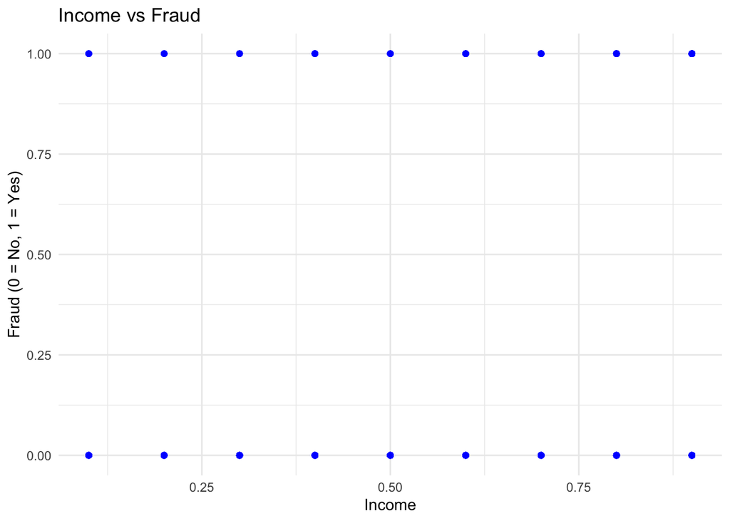

```r
# Scatterplot of income vs fraud_bool
ggplot(bankfraud_base_nomissing, aes(x = income, y = fraud_bool)) +
  geom_point(alpha = 0.5, color = "blue") +
  theme_minimal() +
  labs(title = "Income vs Fraud", x = "Income", y = "Fraud (0 = No, 1 = Yes)")
```

This graphic aids in determining whether income and the probability of fraud are related. For instance, it may indicate that income plays a role in fraud detection if the majority of fraudulent transactions `(fraud_bool = 1)` happen at a given income level. If points are dispersed equally among income levels, on the other hand, it would suggest that fraud is not highly predicted by income.

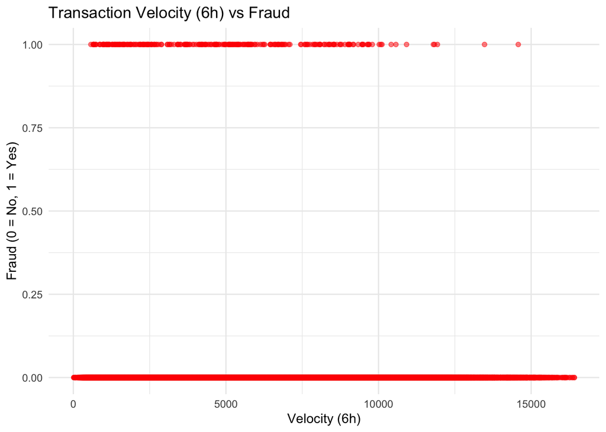

```r
# Scatterplot of velocity_6h vs fraud_bool
ggplot(bankfraud_base_nomissing, aes(x = velocity_6h, y = fraud_bool)) +
  geom_point(alpha = 0.5, color = "red") +
  theme_minimal() +
  labs(title = "Transaction Velocity (6h) vs Fraud", x = "Velocity (6h)", y = "Fraud (0 = No, 1 = Yes)")
```

This plot helps to visually explore whether there is a correlation between high transaction velocity and the likelihood of fraud. If fraudulent transactions `(fraud_bool = 1)` cluster at higher values of `velocity_6h`, it could indicate that high transaction velocity within a short time window is associated with a higher risk of fraud.

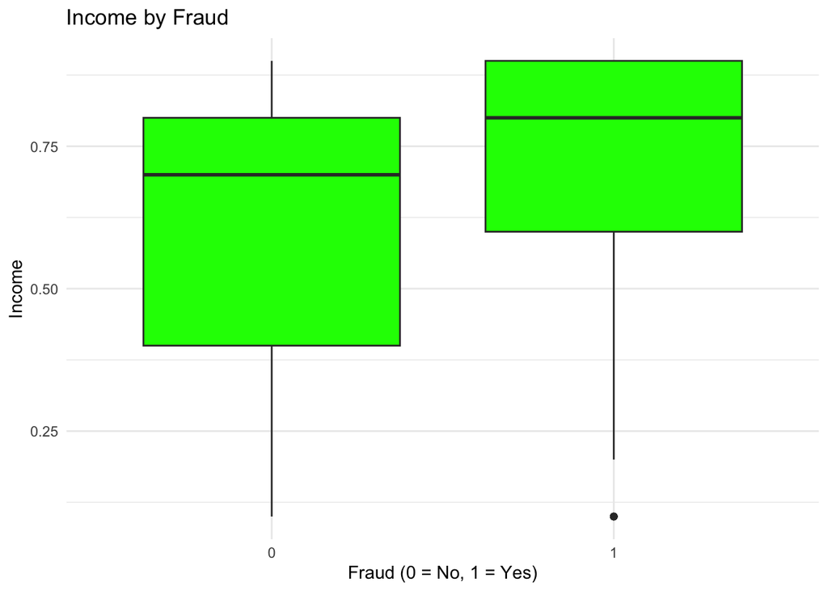

```r
# Boxplot of income by fraud_bool
ggplot(bankfraud_base_nomissing, aes(x = factor(fraud_bool), y = income)) +
  geom_boxplot(fill = "green") +
  theme_minimal() +
  labs(title = "Income by Fraud", x = "Fraud (0 = No, 1 = Yes)", y = "Income")
```

he income distributions for *fraudulent* and *non-fraudulent* transactions can be compared with the aid of this graphic. Variations in the median or range of earnings may indicate a relationship between fraud risk and income.

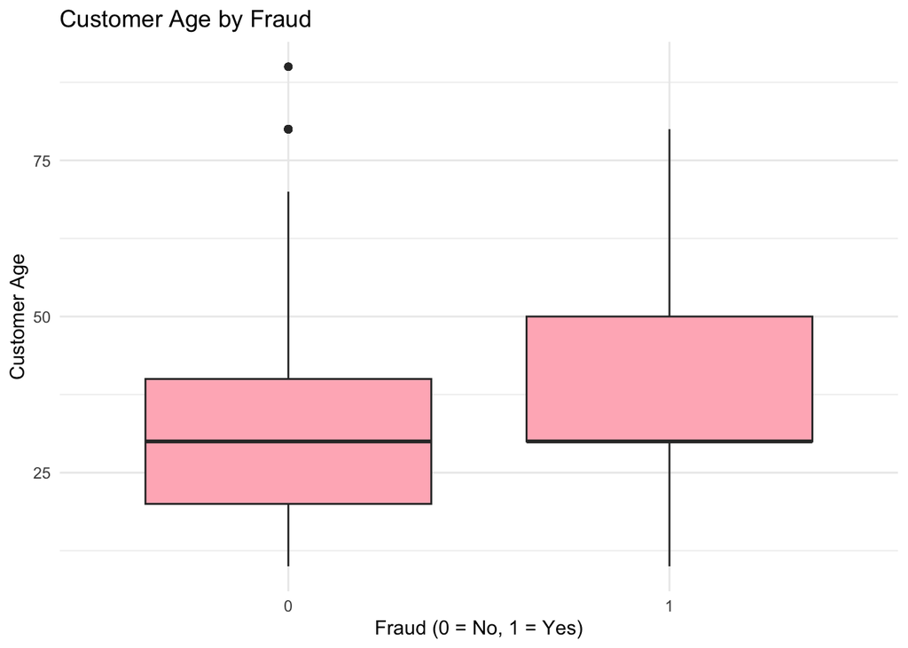

```r
# Boxplot of customer_age by fraud_bool
ggplot(bankfraud_base_nomissing, aes(x = factor(fraud_bool), y = customer_age)) +
  geom_boxplot(fill = "lightpink") +
  theme_minimal() +
  labs(title = "Customer Age by Fraud", x = "Fraud (0 = No, 1 = Yes)", y = "Customer Age")
```

The distribution of `customer_age` for $fraudulent ({1})$ and $non-fraudulent ({0})$ transactions is contrasted in this **boxplot**. The range of consumer ages is displayed on the **Y-axis**, while the **X-axis** indicates the fraud status. Plotting aids in determining whether age disparities between fraud and non-fraud instances are noteworthy, which may assist determine whether age groups are more vulnerable to fraud.

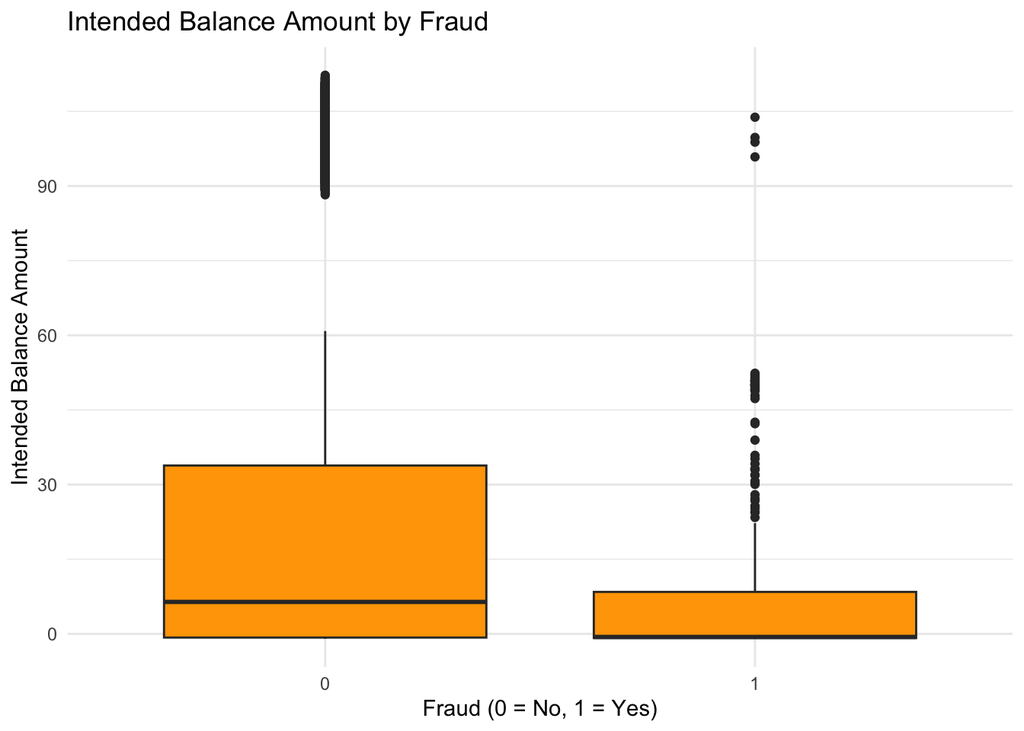

```r
# Boxplot of intended_balcon_amount by fraud_bool
ggplot(bankfraud_base_nomissing, aes(x = factor(fraud_bool), y = intended_balcon_amount)) +
  geom_boxplot(fill = "orange") +
  theme_minimal() +
  labs(title = "Intended Balance Amount by Fraud", x = "Fraud (0 = No, 1 = Yes)", y = "Intended Balance Amount")
```

In addition to possibly indicating whether greater or lower planned balances are associated with a higher risk of fraud, the plot aids in identifying any variations in intended balance amounts between fraud and non-fraud transactions.

## 5. Data Dimension Reduction

**Sample Size:** the total number of observations in the dataset is 124260 observations with 32 variables

**Period:** The Bank Account Fraud (BAF) suite of datasets has been published at NeurIPS 2022

**Outcome Variable:** The outcome we are predicting is fraud_bool, which indicates whether a transaction is fraudulent.

**Reason for reducing the dimensionality of the data:** Increasing Model Efficiency: High-dimensional datasets have the potential to increase the computational cost and interpretive difficulty of models. Process optimization can be achieved by lowering the number of predictors. **Minimizing Noise:** Not every factor influences fraud prediction equally. In order to get rid of features that aren’t significant, dimensionality reduction helps. Certain variables may introduce noise or redundancy. **Concentrating on Key Features:** You can concentrate on the most important factors that genuinely help forecast fraud by lowering dimensionality.